# Introduction to DGVMTools

Matthew Forrest

2020-10-09

## Introduction

DGVMTools is designed to provide core functionality for developing and utilising DGVMs (Dynamic Global Vegetation Models) and similar models (such as Land Surface Models). The basic motivation is that many people work with such models but there is no centralised effort to provide convenient, reliable and efficient tools to perform common tasks such as reading model data, aggregating it in space, time and across vegetation types, producing plots, comparing to standard observed datasets etc. Instead, people develop (and possibly share) scripts on an *ad hoc* basis, often resulting in duplicated effort and technical limitations hindering scientific analysis. DGVMTools aims to provide a common toolbox to enable such tasks.

## Tutorial

Now we’ll jump right in and start using the package to read, process and plot some DGVM output data and hopefully demonstrate the features, logic and power of the package. This tutorial uses small LPJ-GUESS output files included in the package.

### Step 1: Define a **`Source`**

The first job in pretty much any analysis is to define the source (or sources) of the data to be analysed. Here we use the `defineSource()` function to do exactly that, and it produces an object of type `Source`. To define a `Source` we need three key bits of information and these are the three essential arguments to `defineSource()` [^1]. These are:

1. the **`id`** argument, a unique identifier to label this source (should be alphanumeric with no spaces)
2. the **`dir`** argument, to specify the location of the data on disk (for the purposes of this tutorial we generate this with a function, but it is normally just a character string)
3. the **`format`** argument, which specifies the structure of the data on disk (ie what model did it come from)

The `name` argument is optional and can be used to provide a more human-friendly string to identify the run. If it is not provided, the `id` argument is used for the `name`. It is also possible just provide a `name` argument and not an `id` argument, in which case the `id` will be derived from the `name`.

```r
# a little bit of magic to get the path to the example data included in the package on your system
example.run.directory <- system.file("extdata", "LPJ-GUESS_Runs", "CentralEurope", package = "DGVMTools")
print(example.run.directory)
```

```
## [1] "/home/forrest/Tools/R-packages/DGVMTools/inst/extdata/LPJ-GUESS_Runs/CentralEurope"
```

```r
GUESS.run <- defineSource(id = "LPJ-GUESS_Example",
                          dir = example.run.directory, # this would normlly just be a character string containing a path
                          format = GUESS,
                          name = "LPJ-GUESS Example Run")
```

We can check the object’s class take a look at it using the handy `print` function.

```r
class(GUESS.run)
```

```
## [1] "Source"
## attr(,"package")
## [1] "DGVMTools"
```

```r
print(GUESS.run)
```

```
## Source:
##  id = "LPJ-GUESS_Example"
##  name = "LPJ-GUESS Example Run"
##  format = "GUESS"
##  lon-lat offset = (0,0)
##  year offset = 0
##  directory = "/home/forrest/Tools/R-packages/DGVMTools/inst/extdata/LPJ-GUESS_Runs/CentralEurope"
##  forcing data = "Not specified"
##  london.centre = TRUE
##  land.use.included = FALSE
##  institute = "Not specified"
##  contact = "Not specified"
##  PFTs defined:
## BNE BINE BNS IBS TeBE TeNE TeBS TrBE TrIBE TrBR C3G C4G BLSE BLSS C3G_pas C4G_pas CC3G_ic CC4G_ic CC3ann CC3per CC3nfx CC4ann CC4per CC3anni CC3peri CC3nfxi CC4anni CC4peri Crop_sum Pasture_sum Natural_sum Barren_sum Total
```

That looks a little complicated, but it is mostly just meta-data designed to make things more convenient later on (or are needed for special cases such as grid cell coordinates that don’t correspond to the centre of the grid cell), so we can ignore these for just now. Aside from the three obligatory things mentioned above, the only thing that is information about the PFTs in the run, and even that is usually defined automatically in the `format` argument. Note that at this stage we have only created a metadata object. We actually retrieve data in the next step…

### Step 2: Reading data

To actually read data from disk with use the `getField()` function. This can be as simple as the following:

```r
LAI.full <- getField(source = GUESS.run,
                     var = "lai")
```

This step read all the LAI data (across all available space and time) from the source and stores it as a `Field` object. We can have look at this new object using a `print()` command.

```r
print(LAI.full)
```

```
## A Field object
## Quantity:        lai (LAI): Units=m^2/m^2, Defined for format: GUESS, CF name=leaf_area_index
## Id:
##      "LPJ-GUESS_Example.lai.Spatial_Full.2000-2015.Year.none"
## Layers:
##      BNE BINE BNS TeNE TeBS IBS TeBE TrBE TrIBE TrBR C3G C4G Total
## Dimensions:
##      Lon Lat Year
## Spatial Info:
##      Spatial aggregation = none
##      Spatial extent id = Full
##      Spatial extent:
##          class      : Extent
##          xmin       : -5
##          xmax       : 20
##          ymin       : 35
##          ymax       : 60
## Year Info:
##      Yearly aggregation =  none
##      First year = 2000
##      Last year = 2015
## Subannual Info:
##      Subannual original = Year
##      Subannual aggregation = none
##      Subannual resolution = Year
## Data:
##          Lon   Lat Year    BNE   BINE BNS  TeNE   TeBS    IBS   TeBE TrBE TrIBE
##     1: -4.75 35.25 2000 0.0000 0.0000   0 2e-04 0.0000 0.0000 0.8897    0     0
##     2: -4.75 35.25 2001 0.0000 0.0000   0 1e-04 0.0000 0.0000 0.9921    0     0
##     3: -4.75 35.25 2002 0.0000 0.0000   0 1e-04 0.0000 0.0000 1.1937    0     0
##     4: -4.75 35.25 2003 0.0000 0.0000   0 0e+00 0.0000 0.0000 0.7659    0     0
##     5: -4.75 35.25 2004 0.0000 0.0000   0 0e+00 0.0000 0.0000 0.7935    0     0
##    ---
## 23468: 19.75 54.25 2011 0.6364 0.3835   0 0e+00 2.2615 0.7719 0.0000    0     0
## 23469: 19.75 54.25 2012 0.6382 0.3776   0 0e+00 2.3486 0.8067 0.0000    0     0
## 23470: 19.75 54.25 2013 0.6033 0.3477   0 0e+00 2.3071 0.7882 0.0000    0     0
## 23471: 19.75 54.25 2014 0.5765 0.3366   0 0e+00 2.2903 0.7580 0.0000    0     0
## 23472: 19.75 54.25 2015 0.5789 0.3306   0 0e+00 2.2000 0.7106 0.0000    0     0
##        TrBR    C3G C4G  Total
##     1:    0 1.4815   0 2.3714
##     2:    0 1.1930   0 2.1852
##     3:    0 1.5646   0 2.7584
##     4:    0 1.2829   0 2.0488
##     5:    0 1.9035   0 2.6970
##    ---
## 23468:    0 0.0123   0 4.0655
## 23469:    0 0.1039   0 4.2751
## 23470:    0 0.0384   0 4.0847
## 23471:    0 0.0199   0 3.9813
## 23472:    0 0.0111   0 3.8311
##
## Source name:
##       "LPJ-GUESS Example Run"
## (For full Source metadata type "print(object@source)", where X is this Field)
```

This is a lot output but it basically describes everything that you might ever need to know about this `Field`. The most most important part is the data, which is stored in what looks like an R `data.frame` (actually it is a `data.table` which is like a `data.frame` in many ways but often much faster) and each ‘layer’ (in this case each PFT) is stored as a column. There is a bunch of meta-data included too, mostly about the spatial, temporal and annual dimensions of the data. An important piece of metadata in the information about the type of data represented, this is stored in a `Quantity` object. The `Quantity` was looked up automatically from the `var = "lai"` argument.

### Step 3: Aggregating Data

Whilst reading in the entire data set may be useful, it is often to large and unweildy to work with or to plot. When analysing DGVM output, one commonly aggregates the data across space or time. To get the data in a more managable form we are going to call `getField()` two more times, this time making use of its built in **aggregation** options. First we open the file and simulateneously aggregate across all years using the `year.aggregate.method` (in this case we take the mean, but there are other options such as the sum or the variance)

```r
LAI.year.mean <- getField(source = GUESS.run,
                          var = "lai",
                          year.aggregate.method = "mean")
```

To see how this is different to the previous case, we use the `getDimInfo`.

```r
getDimInfo(LAI.full)
```

```
## [1] "Lon"  "Lat"  "Year"
```

```r
getDimInfo(LAI.year.mean)
```

```
## [1] "Lon" "Lat"
```

We can see that the full data (`LAI.full`) has Lon, Lat and Year dimensions, but the yearly aggregated data (`LAI.year.mean`) has only Lon and Lat, since Year has been averaged away.

We can now do a similar thing and aggregate across *space*.

```r
LAI.spatial.mean <- getField(source = GUESS.run,
                             var = "lai",
                             spatial.aggregate.method = "mean")
getDimInfo(LAI.spatial.mean)
```

```
## [1] "Year"
```

Note that this time we have aggregated over space, so the Lon and Lat dimensions have gone, but Year remains.

### Step 4: Plotting data

Having got some sensibly aggregated data, we can now plot it using `plotTemporal` and `plotSpatial`.

#### Spatial plots (maps)

First we us `plotSpatial` to produce a map from the annually-averaged data. Note the underlying plot system is ggplot and `plotSpatial` returns a ggplot2 object which we then need to print in order to actually see it.

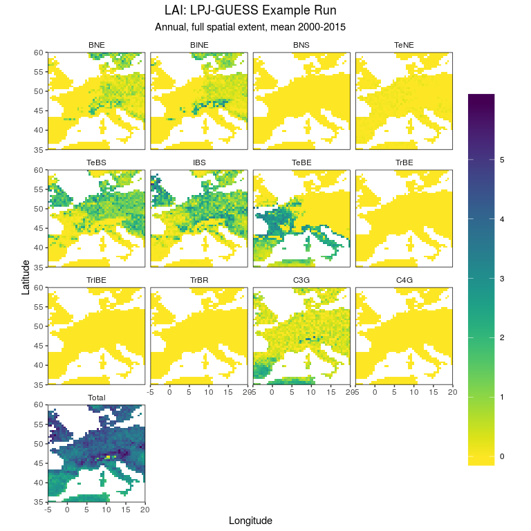

```r
print(plotSpatial(LAI.year.mean))
```

By default all layers are plotted. We can choose one (or more) using the `layers` argument.

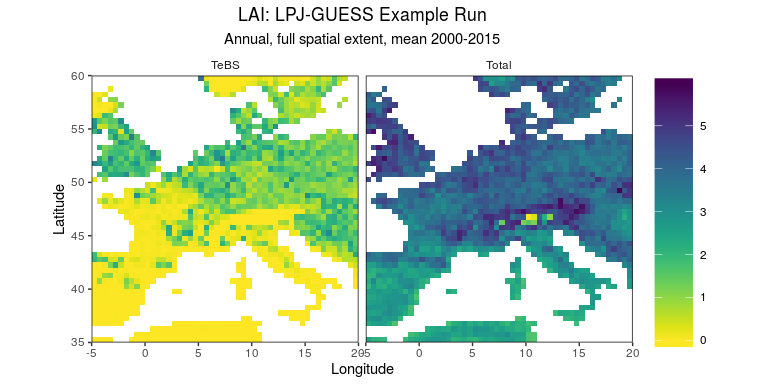

```r
print(plotSpatial(LAI.year.mean, layers = c("TeBS", "Total")))
```

The `plotSpatial` function comes with a lot of arguments which provide a great deal of flexibility. Also, since the the function returns a ggplot object, they can be further modified using standard ggplot commands, which also adds piles of flexibility. There are more examples of this later on.

#### Temporal plots (time series)

The spatially aggregated Field can be plotted as a time series using `plotTemporal`.

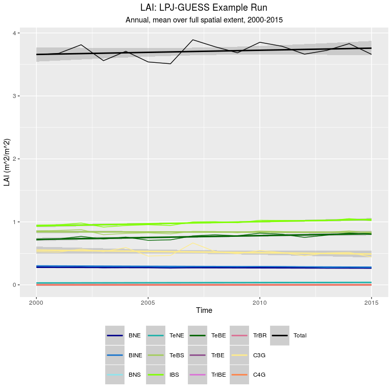

```r
print(plotTemporal(LAI.spatial.mean))
```

And so we see a pretty straightforward times series plot of LAI averaged over the simulated area.

Note that trying to make plots of data with the incorrect dimensions should fail gracefully:

```r
print(plotSpatial(LAI.spatial.mean))
```

[output not shown]

```r
print(plotTemporal(LAI.year.mean))
```

[output not shown]

### Analysis

Having read, aggregated and visualised data, the next steps would likely be further analysis such as aggregating different *layers* (eg combining all tree PFTs), deriving biomes and comparing to data. This section details such operations.

#### Combining layers using `layerOp()`

The `layerOp()` function enables operations on layers, including arithmetic operations (+,-,*,/) and statistical calculations (mean, max, var). Furthermore the `.` (dot) notation allows layers to be selected based on the properties od the corresponsing trees. For example:

```r
# calculate tree total the long way around
LAI.year.mean <- layerOp(x = LAI.year.mean, operator = "+", layers = c("BINE", "BNE", "BNS", "IBS", "TeBS", "TeBE", "TeNE", "TrBE", "TrIBE", "TrBR"), new.layer = "TreeTotal1")

# calculate tree total using dot notation
LAI.year.mean <- layerOp(x = LAI.year.mean, operator = "+", layers = ".Tree", new.layer = "TreeTotal2")

# check the difference (subtract, print and plot)
LAI.year.mean <- layerOp(x = LAI.year.mean, operator = "-", layers = c("TreeTotal1", "TreeTotal2"), new.layer = "TreeTotalDiff")
print(LAI.year.mean)
```

```
## A Field object
## Quantity:        lai (LAI): Units=m^2/m^2, Defined for format: GUESS, CF name=leaf_area_index
## Id:
##      "LPJ-GUESS_Example.lai.Spatial_Full.mean_2000-2015.Year.none"
## Layers:
##      BNE BINE BNS TeNE TeBS IBS TeBE TrBE TrIBE TrBR C3G C4G Total TreeTotal1 TreeTotal2 TreeTotalDiff
## Dimensions:
##      Lon Lat
## Spatial Info:
##      Spatial aggregation = none
##      Spatial extent id = Full
##      Spatial extent:
##          class      : Extent
##          xmin       : -5
##          xmax       : 20
##          ymin       : 35
##          ymax       : 60
## Year Info:
##      Yearly aggregation =  mean
##      First year = 2000
##      Last year = 2015
## Subannual Info:
##      Subannual original = Year
##      Subannual aggregation = none
##      Subannual resolution = Year
## Data:
##         Lon   Lat        BNE      BINE BNS      TeNE      TeBS       IBS
##    1: -4.75 35.25 0.00000000 0.0000000   0 0.0410125 0.0000000 0.0000000
##    2: -4.75 36.75 0.00000000 0.0000000   0 0.0000000 0.0000000 0.0000000
##    3: -4.75 37.25 0.00000000 0.0000000   0 0.1101875 0.0000000 0.0000000
##    4: -4.75 37.75 0.00000000 0.0000000   0 0.0739750 0.0000000 0.0000000
##    5: -4.75 38.25 0.00000000 0.0000000   0 0.1264562 0.0000000 0.0717875
##   ---
## 1463: 19.75 52.25 0.14716875 0.4284062   0 0.0000000 0.9098875 2.0274688
## 1464: 19.75 52.75 0.20576250 0.7681000   0 0.0000000 1.1237188 1.9246375
## 1465: 19.75 53.25 0.55265625 0.4925500   0 0.0000000 1.1101562 1.5608812
## 1466: 19.75 53.75 0.07814375 0.2132938   0 0.0000000 1.1461250 2.1731687
## 1467: 19.75 54.25 0.61311875 0.3941562   0 0.0000000 2.0409375 0.7091937
##            TeBE TrBE TrIBE TrBR        C3G C4G    Total TreeTotal1 TreeTotal2
##    1: 0.8207250    0     0    0 1.60569375   0 2.467431  0.8617375  0.8617375
```

[output cut: 11 more lines]

```
##    1:             0
##    2:             0
##    3:             0
##    4:             0
##    5:             0
##   ---
## 1463:             0
## 1464:             0
## 1465:             0
## 1466:             0
## 1467:             0
##
## Source name:
##       "LPJ-GUESS Example Run"
## (For full Source metadata type "print(object@source)", where X is this Field)
```

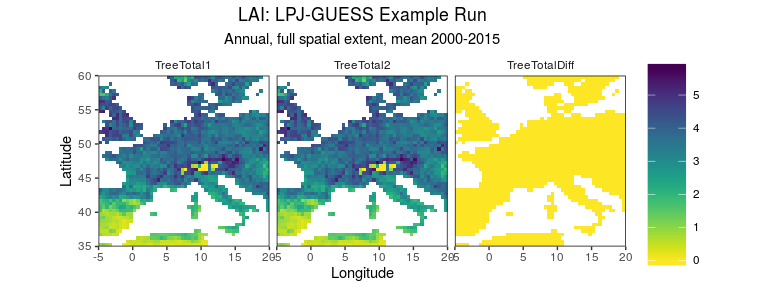

```r
print(plotSpatial(LAI.year.mean, c("TreeTotal1", "TreeTotal2", "TreeTotalDiff")))
```

Selections can also be made on the phenology, climate zone and leaf form of PFT layers. The shorthand `".PFT"` can also be used to select all PFT layers. To calculate the maximum PFT in each gridcell:

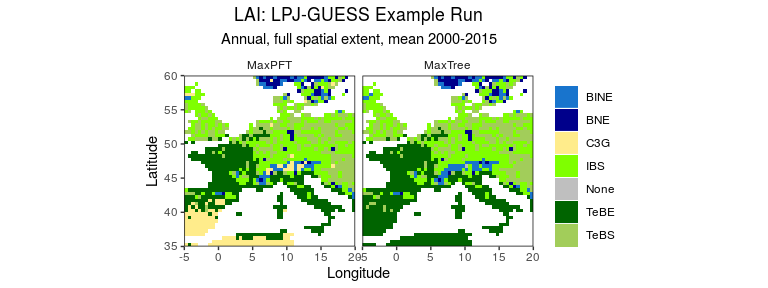

```r
# calculate maximum PFT
LAI.year.mean <- layerOp(LAI.year.mean, "max.layer", ".PFT", "MaxPFT")

# calculate maximum  Tree
LAI.year.mean <- layerOp(LAI.year.mean, "max.layer", ".Tree", "MaxTree")

# plot
print(plotSpatial(LAI.year.mean, c("MaxPFT", "MaxTree")))
```

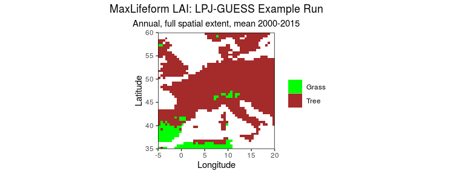

```r
# calculate total tree and grass totals.  Note that further to `"+"` as used above, addition of layers can be defined with the with character string `"sum"` or and arbitary function i.e. `sum`
LAI.year.mean <- layerOp(LAI.year.mean, "sum", ".Grass", "Grass")
LAI.year.mean <- layerOp(LAI.year.mean, sum, ".Tree", "Tree")


# Calculate if trees or grasssis dominant
LAI.year.mean <- layerOp(LAI.year.mean, "max.layer", c("Tree", "Grass"), "MaxLifeform")

# plot
print(plotSpatial(LAI.year.mean, c("MaxLifeform")))
```

Fractions can also be useful:

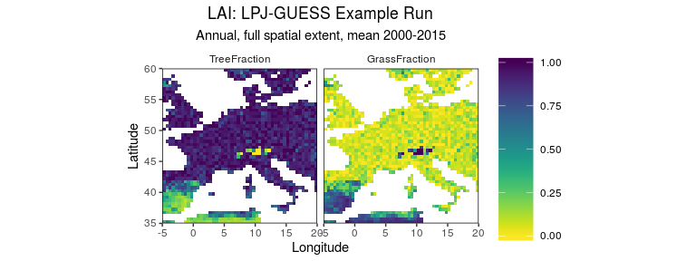

```r
# calculate maximum PFT
LAI.year.mean <- layerOp(LAI.year.mean, "/", c("Tree", "Total"), "TreeFraction")
LAI.year.mean <- layerOp(LAI.year.mean, "/", c("Grass", "Total"), "GrassFraction")

# plot
print(plotSpatial(LAI.year.mean, c("TreeFraction", "GrassFraction")))
```

The `layerOp()` functions is very flexible (it even works with suitable arbitrary functions), see the function documentation for further details. Note that the “-” and “/” operations only work with exactly two input layers given inthe `layers` arguement, and like the rest of the package they follow a “one-two” convention for ordering ie. “layer one minus layer two” or “layer one over layer two”.

#### Reading data and comparing layers

The package can also read datasets that have been processed into the `DGVMData` format. This format is essentially just CF-compliant netCDF, whicha few extra attricute of meta-data. There are a couple of files included in the package, one of which we will use here and compare to another run of LPJ-GUESS, this time cover a part of central-western Africa. Please contact the author if you want more useful data files in the `DGVMData` format.

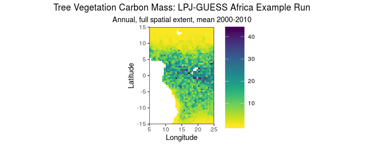

```r
# new Source (different model run, this time over fFrica)
GUESS.Africa.run <- defineSource(id = "LPJ-GUESS_Example_Africa",
                                 dir = system.file("extdata", "LPJ-GUESS_Runs", "CentralAfrica", package = "DGVMTools"),
                                 format = GUESS,
                                 name = "LPJ-GUESS Africa Example Run")

# get standard variable vegC_std between the years 2000 and 2010
GUESS.vegC <- getField(GUESS.Africa.run,
                       "vegC_std",
                       first.year = 2000,
                       last.year = 2010,
                       year.aggregate.method = "mean")

# calculate Tree total and have a plot
GUESS.vegC <- layerOp(GUESS.vegC, "+", ".Tree", "Tree")
print(plotSpatial(GUESS.vegC, "Tree"))
```

```r
# define the data Source (Saatchi biomass data @ HD)
Saatchi.dataset <- defineSource(id = "Saatch2011",
                                name = "Saatchi et al. 2011 tropical biomass",
                                format = DGVMData,
                                dir = system.file("extdata", "DGVMData", "Saatchi2011", "HD", package = "DGVMTools"))

# get the data field
Saatchi.vegC <- getField(source = Saatchi.dataset,
                         var = "vegC_std")

# have a look and plot
print(Saatchi.vegC)
```

```
## A Field object
## Quantity:        vegC_std (Vegetation Carbon Mass): Units=kg m-2, Defined for format: DGVMData, CF name=vegetation_carbon_content
## Id:
##      "Saatch2011.vegC_std.Spatial_SaatchiExtent.all_years"
## Layers:
##      Tree
## Dimensions:
##      Lon Lat
## Spatial Info:
##      Spatial aggregation = none
##      Spatial extent id = SaatchiExtent
##      Spatial extent:
##          class      : Extent
##          xmin       : -114.0009
##          xmax       : 155.9991
##          ymin       : -58.00054
##          ymax       : 39.99946
## Year Info:
##      Yearly aggregation =  none
##      First year =
##      Last year =
## Subannual Info:
##      Subannual original =
##      Subannual aggregation = none
##      Subannual resolution =
## Data:
##            Lon    Lat       Tree
##     1: -112.75 -56.25 0.00000000
##     2: -112.75 -55.75 0.00000000
##     3: -112.75 -55.25 0.00000000
##     4: -112.75 -54.75 0.00000000
##     5: -112.75 -54.25 0.00000000
##    ---
## 71100:  154.75  37.75 0.00000000
## 71101:  154.75  38.25 0.00000000
## 71102:  154.75  38.75 0.00000000
## 71103:  154.75  39.25 0.02000505
## 71104:  154.75  39.75 0.00000000
##
## Source name:
##       "Saatchi et al. 2011 tropical biomass"
## (For full Source metadata type "print(object@source)", where X is this Field)
```

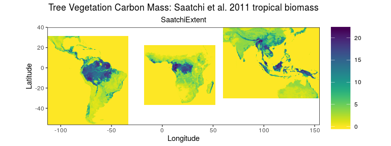

```r
print(plotSpatial(Saatchi.vegC))
```

Now we formally compare the layers using the `compareLayers()` function, which also gives us some comparison metrics. The esulting `Comparison` object can be plotting with `plotSpatialComparison()` and `plotSactterComparison()`.

```r
# compare layers to produce a Comparison object
vegC.comparison <- compareLayers(field1 = GUESS.vegC, field2 = Saatchi.vegC, layers1 = "Tree", layers2 = "Tree", override.quantity = TRUE)
```

```
## [1] "+++ Stats for Tree.LPJ-GUESS_Example_Africa.vegC_std.Spatial_Full.mean_2000-2010.Year.none vs Tree.Saatch2011.vegC_std.Spatial_SaatchiExtent.all_years +++"
## [1] "ME (Mean Error) = 4.1616"
## [1] "NME (Normalised Mean Error) = 0.8128"
## [1] "NMSE (Normalised Mean Square Error) = 0.9839"
## [1] "RMSE (Root Mean Squared Error) = 6.0725"
## [1] "NME_2 (NME with mean removed) = 0.8347"
## [1] "NMSE_2 (NMSE with mean removed) = 0.8376"
## [1] "NME_3 (NME with mean and variance removed) = 0.6443"
## [1] "NMSE_3 (NMSE with mean and variance removed) = 0.4967"
## [1] "r2_eff (Nash-Sutcliffe Model Efficiency) = 0.0161"
## [1] "r (Pearson's PMCC) = 0.7118"
## [1] "r2 (Coefficient of Determination) = 0.5067"
## [1] "m (gradient of linear fit mod = m * obs + c) = 0.9244"
## [1] "c (intercept of linear fit mod = m * obs + c) = 2.8286"
```

```r
# have a look at this comparison object (lots of metadata tracked)
print(vegC.comparison )
```

```
## Comparison Layer:
## id = "Tree.LPJ-GUESS_Example_Africa.vegC_std.Spatial_Full.mean_2000-2010.Year.none-Tree.Saatch2011.vegC_std.Spatial_SaatchiExtent.all_years"
## name = LPJ-GUESS Africa Example Run - Saatchi et al. 2011 tropical biomass"
## type = continuous"
## statistical metrics:
##   ME: 4.16158
##   NME: 0.81277
##   NMSE: 0.98387
##   RMSE: 6.0725
##   NME_2: 0.83471
##   NMSE_2: 0.8376
##   NME_3: 0.64429
##   NMSE_3: 0.49667
##   r2_eff: 0.01613
##   r: 0.71184
##   r2: 0.50672
##   m: 0.92442
##   c: 2.8286
## First layers:
## [1] "Tree"
## [1] "Tree"
## Quantity for first layer:
## Quantity:        vegC_std (Vegetation Carbon Mass): Units=kg m-2, Defined for format: Standard, CF name=vegetation_carbon_content
## Quantity of second layer:
## Quantity:        vegC_std (Vegetation Carbon Mass): Units=kg m-2, Defined for format: DGVMData, CF name=vegetation_carbon_content
## STAInfo for first layer:
## Spatial Info:
##      Spatial aggregation = none
##      Spatial extent id = Full
##      Spatial extent:
##          class      : Extent
##          xmin       : 5
##          xmax       : 25
##          ymin       : -15
##          ymax       : 15
## Year Info:
##      Yearly aggregation =  mean
##      First year = 2000
##      Last year = 2010
## Subannual Info:
```

[output cut: 71 more lines]

```
##  PFTs defined:
## BNE BINE BNS IBS TeBE TeNE TeBS TrBE TrIBE TrBR C3G C4G BLSE BLSS C3G_pas C4G_pas CC3G_ic CC4G_ic CC3ann CC3per CC3nfx CC4ann CC4per CC3anni CC3peri CC3nfxi CC4anni CC4peri Crop_sum Pasture_sum Natural_sum Barren_sum TotalSource for second layer:
## Source:
##  id = "Saatch2011"
##  name = "Saatchi et al. 2011 tropical biomass"
##  format = "DGVMData"
##  lon-lat offset = (0,0)
##  year offset = 0
##  directory = "/home/forrest/Tools/R-packages/DGVMTools/inst/extdata/DGVMData/Saatchi2011/HD"
##  forcing data = "Not specified"
##  london.centre = TRUE
##  land.use.included = FALSE
##  institute = "Not specified"
##  contact = "Not specified"
##  PFTs defined:
```

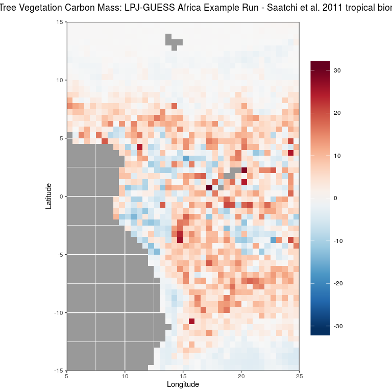

```r
# plot difference map
print(plotSpatialComparison(vegC.comparison))
```

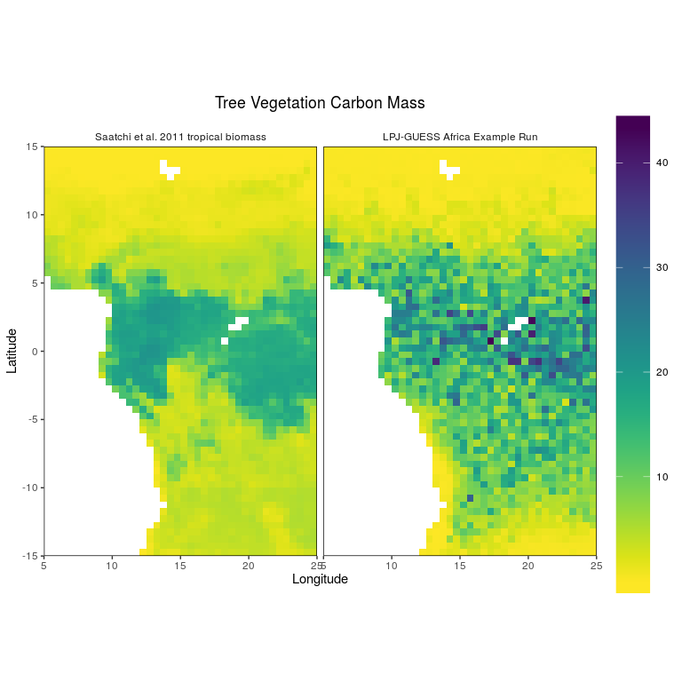

```r
# plot side-by-side
print(plotSpatialComparison(vegC.comparison, type = "values"))
```

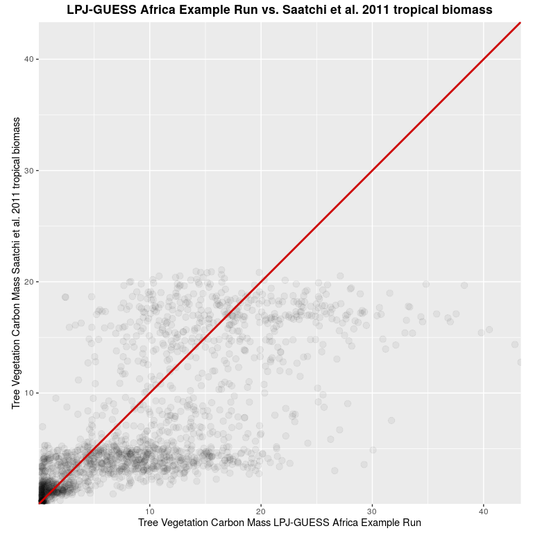

```r
# make scatter plot
print(plotScatterComparison(vegC.comparison))
```

#### Selecting gridcells and plotting the subannual cycle

It is also possible to select gridcells using `selectGridcells()` or the `spatial.extent` argument to getField(). The `spatial.extent` can be a single gridcell (as a numeric two-vector of Lon and Lat),a data.frame or a datat.table with columns Lon and Lat or shapefile (as a SpatialPolygonDataFrame) and anything which can be coerced to a `raster:Extent`. To select rectangular spatial extents, the `raster::crop()` method has been extended. Here we use first make a Field with only one gridcell and then use the `plotSubannual()` function to plot the seasonal cycle. Note that to get the monthly of LAI we are using the `"mlai"` quantity instead of the `"lai"` quantity.

```
## No summary function supplied, defaulting to `mean_se()
```

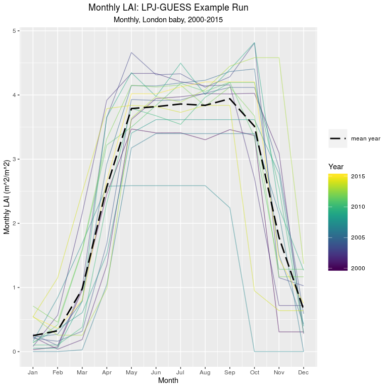

```r
# define a gridecll and the get a Field of the monthly LAI for the gridcell
gridcell <- data.frame(Lon = c(0.25), Lat = c(51.25))
London.mlai <- getField(source = GUESS.run,
                     var = "mlai",
                     spatial.extent = gridcell,
                     spatial.extent.id = "London baby")


# plot LAI
print(plotSubannual(field = London.mlai,
                   col.by = "Year",
                   alpha = 0.5))
```

#### Calculating biomes and categorical comparisons

The `getScheme()` function can be used to classify model output into some pre-defined classification categories. Here we classify vegetation into global biomes.

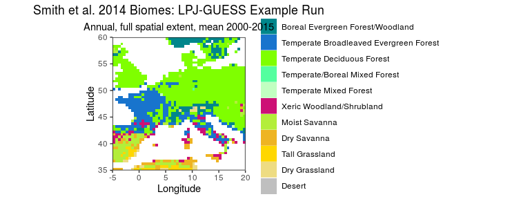

```r
# read and plot global biomes
biomes.model <- getScheme(GUESS.run, Smith2014BiomeScheme, year.aggregate.method = "mean")
#print(plotSpatial(biomes.model, map.overlay = "world"))
print(plotSpatial(biomes.model))
```

There is also a global map on potential natural vegetation (PNV) biomes available.

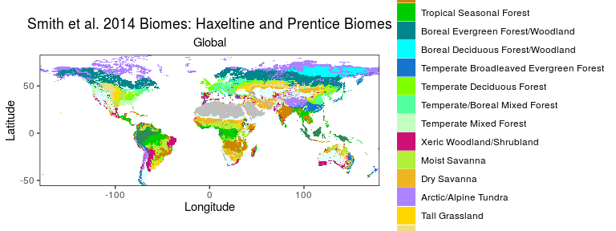

```r
# data biomes source
biomes.source <- defineSource(id = "DataBiomes",
                              dir = system.file("extdata", "DGVMData", "HandP_PNV", "HD", package = "DGVMTools"),
                              format = DGVMData,
                              name = "Haxeltine and Prentice Biomes")
biomes.data <- getField(source = biomes.source, var = "Smith2014")
print(plotSpatial(biomes.data))
```

The `compareLayers()` function automatically detects categorical quantities such as biomes and treats them accordingly.

```r
biome.comparison <- compareLayers(field1 = biomes.model, field2 = biomes.data, layers1 = "Smith2014", layers2 = "Smith2014")
```

```
## [1] "+++ Stats for Smith2014.LPJ-GUESS_Example.Smith2014.Spatial_Full.mean_2000-2015.Year.none vs Smith2014.DataBiomes.Smith2014.Spatial_Global.all_years +++"
## [1] "Kappa (Overall Cohen's Kappa) = 0.0589"
## [1] "Individual Kappas:"
## [1] "   Arid Shrubland/Steppe = 0"
## [1] "   Boreal Evergreen Forest/Woodland = 0.3484"
## [1] "   Desert = 0"
## [1] "   Dry Grassland = 0"
## [1] "   Dry Savanna = 0.0777"
## [1] "   Moist Savanna = 0.1061"
## [1] "   Tall Grassland = 0"
## [1] "   Temperate Broadleaved Evergreen Forest = 0.0352"
## [1] "   Temperate Deciduous Forest = 0.0431"
## [1] "   Temperate Mixed Forest = -0.0028"
## [1] "   Temperate/Boreal Mixed Forest = 0.0019"
## [1] "   Tropical Deciduous Forest = 0"
## [1] "   Xeric Woodland/Shrubland = 0.1055"
```

```r
# have a look at this comparison object
print(biome.comparison )
```

```
## Comparison Layer:
## id = "Smith2014.LPJ-GUESS_Example.Smith2014.Spatial_Full.mean_2000-2015.Year.none-Smith2014.DataBiomes.Smith2014.Spatial_Global.all_years"
## name = LPJ-GUESS Example Run vs. Haxeltine and Prentice Biomes"
## type = categorical"
## statistical metrics:
##   Kappa: 0.05892
## [1] "Boreal Evergreen Forest/Woodland:\n"
##     Arid Shrubland/Steppe: 0
##     Boreal Evergreen Forest/Woodland: 0.34839
##     Desert: 0
##     Dry Grassland: 0
##     Dry Savanna: 0.07765
##     Moist Savanna: 0.1061
##     Tall Grassland: 0
##     Temperate Broadleaved Evergreen Forest: 0.03515
##     Temperate Deciduous Forest: 0.04313
##     Temperate Mixed Forest: -0.00282
##     Temperate/Boreal Mixed Forest: 0.00186
##     Tropical Deciduous Forest: 0
##     Xeric Woodland/Shrubland: 0.1055
## First layers:
## [1] "Smith2014"
## [1] "Smith2014"
## Quantity for first layer:
## Quantity:        Smith2014 (Smith et al. 2014 Biomes): Units=Tropical Rain Forest, Defined for format: LPJ-GUESS, LPJ-GUESS-SPITFIRE, CF name=unknown
##  Quantity:       Smith2014 (Smith et al. 2014 Biomes): Units=Tropical Deciduous Forest, Defined for format: LPJ-GUESS, LPJ-GUESS-SPITFIRE, CF name=unknown
##  Quantity:       Smith2014 (Smith et al. 2014 Biomes): Units=Tropical Seasonal Forest, Defined for format: LPJ-GUESS, LPJ-GUESS-SPITFIRE, CF name=unknown
##  Quantity:       Smith2014 (Smith et al. 2014 Biomes): Units=Boreal Evergreen Forest/Woodland, Defined for format: LPJ-GUESS, LPJ-GUESS-SPITFIRE, CF name=unknown
##  Quantity:       Smith2014 (Smith et al. 2014 Biomes): Units=Boreal Deciduous Forest/Woodland, Defined for format: LPJ-GUESS, LPJ-GUESS-SPITFIRE, CF name=unknown
##  Quantity:       Smith2014 (Smith et al. 2014 Biomes): Units=Temperate Broadleaved Evergreen Forest, Defined for format: LPJ-GUESS, LPJ-GUESS-SPITFIRE, CF name=unknown
##  Quantity:       Smith2014 (Smith et al. 2014 Biomes): Units=Temperate Deciduous Forest, Defined for format: LPJ-GUESS, LPJ-GUESS-SPITFIRE, CF name=unknown
##  Quantity:       Smith2014 (Smith et al. 2014 Biomes): Units=Temperate/Boreal Mixed Forest, Defined for format: LPJ-GUESS, LPJ-GUESS-SPITFIRE, CF name=unknown
##  Quantity:       Smith2014 (Smith et al. 2014 Biomes): Units=Temperate Mixed Forest, Defined for format: LPJ-GUESS, LPJ-GUESS-SPITFIRE, CF name=unknown
##  Quantity:       Smith2014 (Smith et al. 2014 Biomes): Units=Xeric Woodland/Shrubland, Defined for format: LPJ-GUESS, LPJ-GUESS-SPITFIRE, CF name=unknown
##  Quantity:       Smith2014 (Smith et al. 2014 Biomes): Units=Moist Savanna, Defined for format: LPJ-GUESS, LPJ-GUESS-SPITFIRE, CF name=unknown
##  Quantity:       Smith2014 (Smith et al. 2014 Biomes): Units=Dry Savanna, Defined for format: LPJ-GUESS, LPJ-GUESS-SPITFIRE, CF name=unknown
##  Quantity:       Smith2014 (Smith et al. 2014 Biomes): Units=Arctic/Alpine Tundra, Defined for format: LPJ-GUESS, LPJ-GUESS-SPITFIRE, CF name=unknown
##  Quantity:       Smith2014 (Smith et al. 2014 Biomes): Units=Tall Grassland, Defined for format: LPJ-GUESS, LPJ-GUESS-SPITFIRE, CF name=unknown
##  Quantity:       Smith2014 (Smith et al. 2014 Biomes): Units=Dry Grassland, Defined for format: LPJ-GUESS, LPJ-GUESS-SPITFIRE, CF name=unknown
##  Quantity:       Smith2014 (Smith et al. 2014 Biomes): Units=Arid Shrubland/Steppe, Defined for format: LPJ-GUESS, LPJ-GUESS-SPITFIRE, CF name=unknown
```

[output cut: 105 more lines]

```
##  PFTs defined:
## BNE BINE BNS IBS TeBE TeNE TeBS TrBE TrIBE TrBR C3G C4G BLSE BLSS C3G_pas C4G_pas CC3G_ic CC4G_ic CC3ann CC3per CC3nfx CC4ann CC4per CC3anni CC3peri CC3nfxi CC4anni CC4peri Crop_sum Pasture_sum Natural_sum Barren_sum TotalSource for second layer:
## Source:
##  id = "DataBiomes"
##  name = "Haxeltine and Prentice Biomes"
##  format = "DGVMData"
##  lon-lat offset = (0,0)
##  year offset = 0
##  directory = "/home/forrest/Tools/R-packages/DGVMTools/inst/extdata/DGVMData/HandP_PNV/HD"
##  forcing data = "Not specified"
##  london.centre = TRUE
##  land.use.included = FALSE
##  institute = "Not specified"
##  contact = "Not specified"
##  PFTs defined:
```

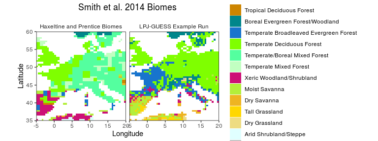

```r
# plot side-by-side
print(plotSpatialComparison(biome.comparison, type = "values"))
```

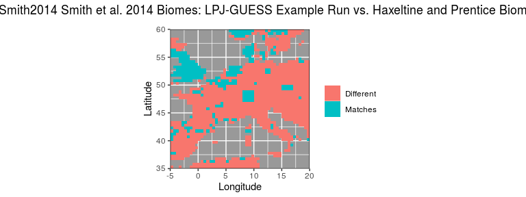

```r
# plot difference map
print(plotSpatialComparison(biome.comparison, type = "difference"))
```

### Customising your plots (ggplot2)

#### Changing facet layouts

The plotting functions always adds a column called `Facet` by which to facet the data. Facet layout can be adjusted as follows:

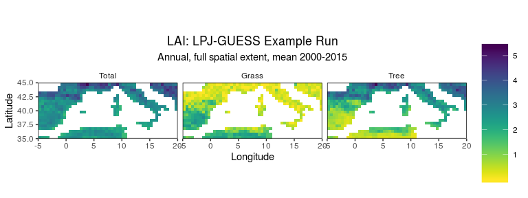

```r
# make a plot with silly facets
lifeform.plot <- plotSpatial(LAI.year.mean, layers = c("Tree", "Grass", "Total"), ylim = c(35,45))
print(lifeform.plot)
```

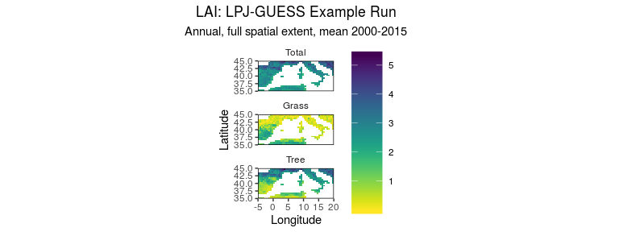

```r
# arrange facets with three rows
lifeform.plot <- lifeform.plot + facet_wrap(~Facet, nrow =3)
print(lifeform.plot)
```

#### Formatting legends and text

The `theme()` and `guides()` functions are very handy. See ggplot2 documentation for more info.

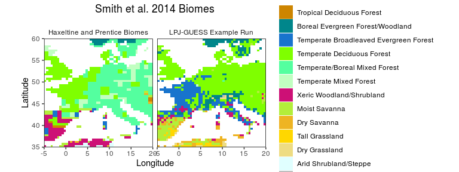

```r
# ove and format legends, and make the text slightly smaller
biome.plot <- plotSpatialComparison(biome.comparison, type = "values")
print(biome.plot)
```

[figure not shown]

```r
biome.plot <- biome.plot + theme(legend.position = "bottom", text = element_text(size = theme_get()$text$size * 0.75))
biome.plot <- biome.plot+ guides(fill = guide_legend(ncol = 2))
print(biome.plot)
```

## Further Details

Whilst the tutorial above will get you started with the package, the following will give you further information and a deeper understanding of the package and is recommended reading.

### Objects/classes

Concepts in a typical DGVM workflow are encapsulated into objects (technically these are S4 classes). For example, data always orginate from a particular source, typically a model simulation or a dataset. This is represented as a `Source` object, which includes the location of the data on disk, an identifying string and other pertinent pieces of information. Once a `Source` has been defined, data can be extracted from it which will be stored as a `Field` object. Conceptually, a `Field` is the data of one particular variable (say biomass) over a period of time and an extent in space (say monthly over the whole globe for the years 1961 to 1990). `Fields` are the most important objects in DGVMTools because they are manipulated by the users and they contain data (most other classes are metadata). One can think of a `Field` as being similar to raster Stacks or Bricks, but with more metadata and implicit temporal information. Like Stacks/Bricks, they also have layers, for example one layer per PFT. These layers can be operated upon, for example to find the total of all of the layers, or the fraction of one layer divided another, or many other operations. They can also be plotted, and two `Field` objects can be compared to produce a `Comparison` object which has data on the difference between the two fields and statistical summary metrics.

Apart from the all-important `Field`and `Source` (and `Comparison`) objects, there are a few other objects defined in DGVMTools. Each `Source` object includes `Format` object which describes the format of that data on disk - i.e. how to read data from it, which PFTs one might expect to find in a simulation etc. Different physical quantities are described by `Quantity` objects which include units, a long name and a default colour scale for plotting. A `Layer` object contains metadata about a component of a `Field`, for example a particular plant functional type or C pool. It can include metadata such as its growth form, phenology, leaf type or climate zone, but also a default colour for consistency across plots. The `Period` class contains information about sub-annual time periods such as months or seasons. Users can also define custom periods to define special growing seasons, or 8-day MODIS intervals, or whatever. The `BiomeScheme` class contains data about different discrete biome classifications (including rules for how to derive biomes from model output). Oh yeah, spatial-temporal-annual information is encapsulated in an `STAInfo` meta-data object but this mostly is used behind the scenes.

Many objects have an `id` which should be a unique alphanumeric character string, typically used for making filenames, and a `name` character string which can be formatted more prettily for use on graphics (although it should also be unique within one analysis). Examples of most of these objects will follow in the subsequent tutorial.

### Functions/methods

Obviously there are quite a lot of the fuctions in the package as it aims to go from raw model output data to publication-quality plots. Typically a script will start with calls to `defineSource()` to initialise one or more `Source` objects. The next step might be to call `getField()` which actually extracts data from the `Source` and builds a `Field` objects. The `getField()` function has options for selecting data in space and time, and also for aggregating it (for example to calculate the average of all years, or the total across a region). However you can further refine the spatial-temporal dimensions of `Field` by applying the `aggregate` family of functions (`aggregateSpatial()`, `aggregateYears()` and `aggregateSubannual()`) or the `select` family of function (`selectGridcells()`, `selectMonth()`, `selectYears()`, `selectSeasons()`) and the `crop()` method (which crops the spatial extent exactly like the `raster::crop` function, indeed, it even work with raster objects).

Having sorted out the spatial and temporal dimemsions, you can then manipulation the `Field` and plot it. Rember that data is stored as ‘layers’ similar to GIS and raster? To combine layers and perform other operations one can use the `layerOp()` function which supports arithmetic operators (+,-,/,*), finding maximum and minimums of a group of layers, and the mean, standard deviation and variance across layers. One can plot layers in spatial layers (i.e. maps) with `plotSpatial()` and temporal layers (time series) with `plotTemporal()`. Two layers can be quickly compared with a scatter plot using `plotScatter()`. For a more rigorous comparison, one can use `compareLayers()` to a produce a `Comparison` objects which can be plotted in a variety of ways with dedicated functions.

### `whichLayers()` and the `.Layer` (dot-layer) notation for the `layerOp()` function

One special feature of DGVMTools that deserves it own mention at this point is the `.Layer` (dot-layer) short-hand notation that can be used with `layerOp()`. The allows the selecting of layers based on PFT metadata. For example `.Tree` will select all layers corresponding to a tree PFT. `.Evergreen` will select all layers with evergreen phenology, `.Boreal` will choose all PFTs associated with the boreal zone, etc. This is done by a hidden call to the useful function `whichLayers()` which allows you to list all PFTs in a `Field`, or to list all PFTs based on a criteria (say ‘Tree’, ‘Evergreen’ or ‘Boreal’ as above.)

### Applicability

The package treats model output and observed data in an equivalent fashion and so is equally useful for model-to-data, model-to-model and data-to-data analyses. A companion R package DGVMData reads data from a variety of sources (primarly satellite data) and formats it such that it can be read natively by DGVMTools (this is basically just CF-compliant netCDF files with a couple of extra attributes).

Much of the package could be utilised for any data which follows comes distributed over space (longitude, latitude), time (multiple years of data with subannual time resolution of daily, monthly or annual) and and different conceptual layers (for example different vegetation types or soil carbon pools). However it has several additional features which are focussed on vegetation modelling, namely: the ability to read data from selected DGVMs in their native formats (currently LPJ-GUESS(-SPITFIRE) and aDGVM2 are supported); facilities for handling metadata about Plant Functional Types (PFTs); and the means to classify vegetation model output into biomes.

### Miscellaneous details

- DGVMTools objects can be really easily converted into rasters or data.frames, so you can mix and match the functionality you want and integrate DGVMTools into existing scripts.
- For speed, the data is stored internally as `data.table` objects which are similar to `data.frames` but faster.
- Although the concept of a ‘layer’ is important in `DGVMTools`, they are not represented by a class. Rather they are column in a `data.table`. Normally this technical detail is not apparent or important because the columns/layers are manipulated using the functions in the package without handling the `data.tables` directly.
- `Field` objects can be stored on disk and automatically re-read by the `getField()` function, potentionally saving a lot of time (since often the bottle neck in analysis scripts is reading the raw data from disk).
- Plotting is done using the package ggplot which is especially useful as plots can be modified after they have been created (much more flexibly than base or lattice graphics). This maintains relative simplicity in the DGVMTools plot function, but high levels of flexibility through subsequent modifications with ggplot2 commands.
- Unlike raster objects, `Field`s do not need to be on grids of equally spaced longitude and latitude, or even on grids at all! This is handy when working with sites, or with grid from climate models which often have unevenly spaced latitudes.
- Regridding is not really supporting by DGVMTools, although there is a wrapper to the `cdo` (climate data operators package) included which handles some regridding (if `cdo` is installed).
[^1]: Experienced R users may have noticed that here we are using a specific function to make out `Source` object as opposed to `new()` function. Whilst it is possible to construct a `Source` using `new()` it is **strongly recommended not to do so** because using `defineSource()` is safer as it ensures the integrity and internal consistency of the `Source`. It is also just *very* much more convenient.